# CS 346 Final Project

Julia Hartnett

```r
#install.packages("fastDummies")
library(fastDummies)
library(tidyverse)
library(rpart)
library(caret)
library(randomForest)
require(caTools)
library(tidyverse)
library(neuralnet)
library(e1071)
set.seed(5)
```

My data set is from Kaggle and contains information about packages. The target is whether or not the package was received on time. A 1 means the the package was *not* received on time, and a 0 means that it was.

## Data Transformations

Things to consider:

- split multi-attribute categories
- bin/discretize numeric data
- remove attributes
- scaling
- missing values
- nominal to numeric
- feature importance
- redundant attributes

```r
shipping = read.csv(file = '~/School Work/SP21/Data Mining - CS 346/shipping.csv')
```

### Checking Missing Values:

```r
summary(shipping)
```

```
##      ï..ID       Warehouse_block    Mode_of_Shipment   Customer_care_calls
##  Min.   :    1   Length:10999       Length:10999       Min.   :2.000
##  1st Qu.: 2750   Class :character   Class :character   1st Qu.:3.000
##  Median : 5500   Mode  :character   Mode  :character   Median :4.000
##  Mean   : 5500                                         Mean   :4.054
##  3rd Qu.: 8250                                         3rd Qu.:5.000
##  Max.   :10999                                         Max.   :7.000
##  Customer_rating Cost_of_the_Product Prior_purchases  Product_importance
##  Min.   :1.000   Min.   : 96.0       Min.   : 2.000   Length:10999
##  1st Qu.:2.000   1st Qu.:169.0       1st Qu.: 3.000   Class :character
##  Median :3.000   Median :214.0       Median : 3.000   Mode  :character
##  Mean   :2.991   Mean   :210.2       Mean   : 3.568
##  3rd Qu.:4.000   3rd Qu.:251.0       3rd Qu.: 4.000
##  Max.   :5.000   Max.   :310.0       Max.   :10.000
##     Gender          Discount_offered Weight_in_gms  Reached.on.Time_Y.N
##  Length:10999       Min.   : 1.00    Min.   :1001   Min.   :0.0000
##  Class :character   1st Qu.: 4.00    1st Qu.:1840   1st Qu.:0.0000
##  Mode  :character   Median : 7.00    Median :4149   Median :1.0000
##                     Mean   :13.37    Mean   :3634   Mean   :0.5967
##                     3rd Qu.:10.00    3rd Qu.:5050   3rd Qu.:1.0000
##                     Max.   :65.00    Max.   :7846   Max.   :1.0000
```

```r
table(is.na(shipping))
```

```
##
##  FALSE
## 131988
```

There are no missing values in the data.

### Split categorical values into numerical

```r
shipping_new = dummy_cols(shipping, select_columns = c("Warehouse_block", "Mode_of_Shipment", "Product_importance", "Gender"))


shipping_new = shipping_new %>%
    select(-c("Warehouse_block", "Mode_of_Shipment", "Product_importance", "Gender", "ï..ID"))

shipping = shipping %>%
    select(-"ï..ID")

shipping$Reached.on.Time_Y.N = as.factor(shipping$Reached.on.Time_Y.N)

shipping_new$Reached.on.Time_Y.N = as.factor(shipping_new$Reached.on.Time_Y.N)
```

The variables ‘Warehouse_block’, ‘Mode_of_Shipment’, ‘Product_importance’, and ‘Gender’ were categorical variables that needed to be split into 0/1 numerical values to use certain models. I also changed the target column to be a factor in this step.

### Remove Attributes

After transforming the columns, I removed the original columns from the data. I also removed the ‘id’ column since it was not useful for the analysis.

### Scaling

In order to use SVM and neural nets, the numerical values need to be scaled. I scaled ‘Customer_care_calls’, ‘Customer_rating’, ‘Cost_of_the_Product’, ‘Prior_purchases’, ‘Discount_offered’, and ‘Weight_in_gms’.

```r
normalize <- function(x) {
return ((x - min(x)) / (max(x) - min(x)))
}

shipping_new$Customer_care_calls = normalize(shipping_new$Customer_care_calls)
shipping_new$Customer_rating = normalize(shipping_new$Customer_rating)
shipping_new$Cost_of_the_Product = normalize(shipping_new$Cost_of_the_Product)
shipping_new$Prior_purchases = normalize(shipping_new$Prior_purchases)
shipping_new$Discount_offered = normalize(shipping_new$Discount_offered)
shipping_new$Weight_in_gms = normalize(shipping_new$Weight_in_gms)
```

### Redundant Attributes

I don’t think there are any redundant columns in the data

### Nominal Attributes

I also don’t think there are any nominal attributes.

### Breakdown of target column

This was to check how many of each class of the target variable there were, so that when comparing accuracy of my models I can decide if the accuracy is better than a random guess.

```r
shipping %>%
  count(Reached.on.Time_Y.N)
```

| Reached.on.Time_Y.N | n |
| --- | --- |
| 0 | 4436 |
| 1 | 6563 |

```r
4436/(4436 + 6563)
```

```
## [1] 0.4033094
```

```r
6563/(4436 + 6563)
```

```
## [1] 0.5966906
```

## Testing Data on a Decision Tree

Before doing any of the more complicated models, I ran a simple decision tree with my data. For the decision tree I used the version of my data set with no scaled values and the categorical values, since a decision tree does not require scaled numeric data. I split my data into a training and testing set before running.

```r
require(caTools)
sample = sample.split(shipping, SplitRatio = .75)
train = subset(shipping, sample == TRUE)
test  = subset(shipping, sample == FALSE)

train$Reached.on.Time_Y.N = as.factor(train$Reached.on.Time_Y.N)
test$Reached.on.Time_Y.N = as.factor(test$Reached.on.Time_Y.N)
```

```r
set.seed(5)
fit <- rpart(Reached.on.Time_Y.N ~ .,
             method="class", data=train)

printcp(fit) # display the results
```

```
##
## Classification tree:
## rpart(formula = Reached.on.Time_Y.N ~ ., data = train, method = "class")
##
## Variables actually used in tree construction:
## [1] Discount_offered Prior_purchases  Weight_in_gms
##
## Root node error: 3218/7999 = 0.4023
##
## n= 7999
##
##         CP nsplit rel error  xerror     xstd
## 1 0.114357      0   1.00000 1.00000 0.013629
## 2 0.064947      1   0.88564 0.88564 0.013310
## 3 0.018956      2   0.82070 0.82474 0.013086
## 4 0.017402      3   0.80174 0.82474 0.013086
## 5 0.010000      4   0.78434 0.79304 0.012954
```

```r
summary(fit) # detailed summary of splits
```

```
## Call:
## rpart(formula = Reached.on.Time_Y.N ~ ., data = train, method = "class")
##   n= 7999
##
##           CP nsplit rel error    xerror       xstd
## 1 0.11435674      0 1.0000000 1.0000000 0.01362851
## 2 0.06494717      1 0.8856433 0.8856433 0.01331006
## 3 0.01895587      2 0.8206961 0.8247359 0.01308641
## 4 0.01740211      3 0.8017402 0.8247359 0.01308641
## 5 0.01000000      4 0.7843381 0.7930392 0.01295434
##
## Variable importance
##    Discount_offered       Weight_in_gms     Prior_purchases Cost_of_the_Product
##                  74                  14                   7                   2
## Customer_care_calls
##                   2
##
## Node number 1: 7999 observations,    complexity param=0.1143567
##   predicted class=1  expected loss=0.4023003  P(node) =1
##     class counts:  3218  4781
##    probabilities: 0.402 0.598
##   left son=2 (6068 obs) right son=3 (1931 obs)
##   Primary splits:
##       Discount_offered    < 10.5   to the left,  improve=823.95420, (0 missing)
##       Weight_in_gms       < 3998.5 to the right, improve=496.71680, (0 missing)
##       Prior_purchases     < 3.5    to the right, improve= 38.48993, (0 missing)
##       Cost_of_the_Product < 210.5  to the right, improve= 23.89556, (0 missing)
##       Customer_care_calls < 5.5    to the right, improve= 16.75553, (0 missing)
##   Surrogate splits:
##       Weight_in_gms < 3998.5 to the right, agree=0.782, adj=0.097, (0 split)
##
## Node number 2: 6068 observations,    complexity param=0.06494717
##   predicted class=0  expected loss=0.469677  P(node) =0.7585948
##     class counts:  3218  2850
##    probabilities: 0.530 0.470
##   left son=4 (4073 obs) right son=5 (1995 obs)
##   Primary splits:
##       Weight_in_gms       < 4108.5 to the right, improve=40.659000, (0 missing)
##       Product_importance  splits as  RLL,        improve= 3.958497, (0 missing)
##       Prior_purchases     < 3.5    to the right, improve= 2.855421, (0 missing)
```

[output cut: 48 more lines]

```
##
## Node number 11: 474 observations
##   predicted class=1  expected loss=0.2151899  P(node) =0.05925741
##     class counts:   102   372
##    probabilities: 0.215 0.785
##
## Node number 20: 1377 observations
##   predicted class=0  expected loss=0.4575163  P(node) =0.1721465
##     class counts:   747   630
##    probabilities: 0.542 0.458
##
## Node number 21: 144 observations
##   predicted class=1  expected loss=0.3055556  P(node) =0.01800225
##     class counts:    44   100
##    probabilities: 0.306 0.694
```

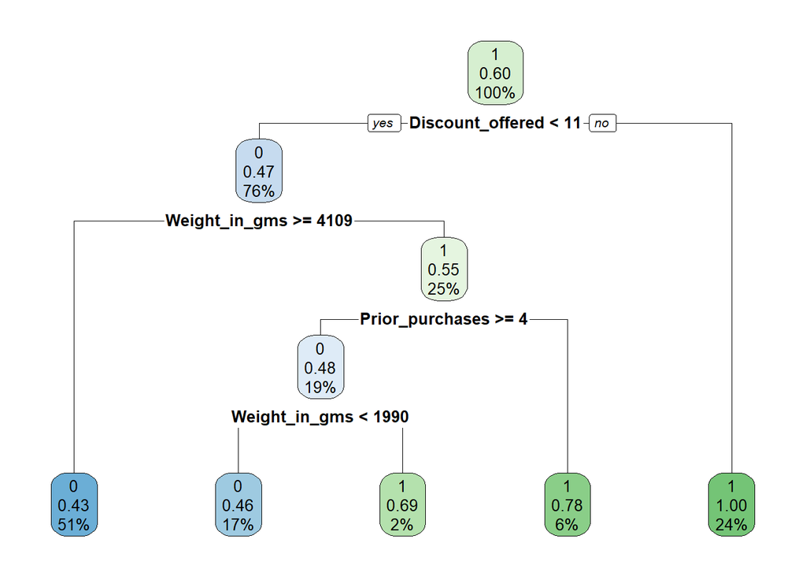

```r
rpart.plot::rpart.plot(fit)
```

```r
predict_unseen <-predict(fit, test, type = 'class')
table_mat <- table(test$Reached.on.Time_Y.N, predict_unseen)
table_mat
```

```
##    predict_unseen
##        0    1
##   0 1157   61
##   1  895  887
```

```r
accuracy_Test <- sum(diag(table_mat)) / sum(table_mat)
accuracy_Test
```

```
## [1] 0.6813333
```

After generating predictions using my test set and creating a confusion matrix, we can see that the decision tree was 68% accurate. The main reason for doing a decision tree was to see if the data would work when using modeling techniques and to be able to run feature importance.

### Feature Importance from Decision Tree

```r
imp = varImp(fit, scale = FALSE)
imp
```

|  | Overall |
| --- | --- |
| Cost_of_the_Product | 88.158995 |
| Customer_care_calls | 48.133064 |
| Customer_rating | 1.837483 |
| Discount_offered | 823.954216 |
| Prior_purchases | 117.713464 |
| Product_importance | 11.751096 |
| Weight_in_gms | 587.193451 |
| Warehouse_block | 0.000000 |
| Mode_of_Shipment | 0.000000 |
| Gender | 0.000000 |

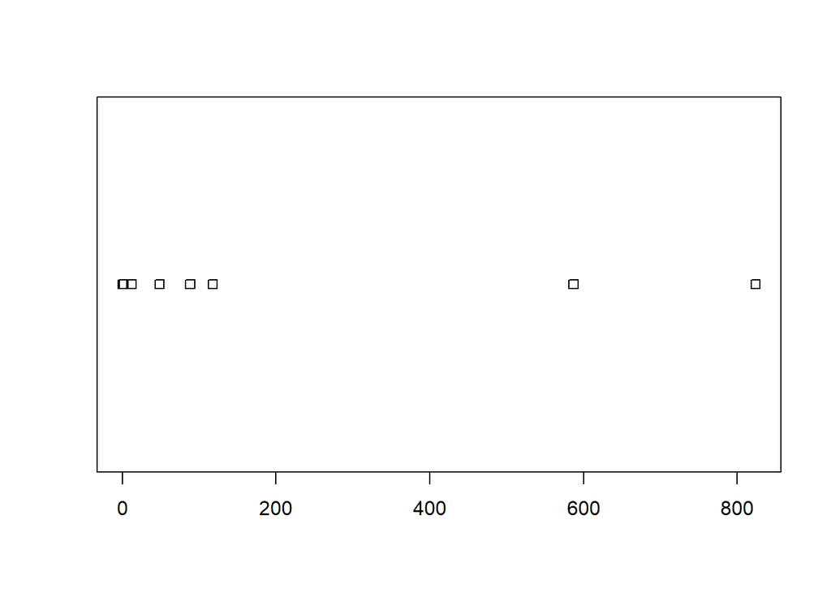

```r
plot(imp)
```

## Random Forest on All Variables

The first more advanced model I ran was a random forest. I ran the random forest on all of the variables in the data using the original version of the data since a random forest can handle categorical and unscaled data. I used the same training and testing data that I created when running the decision tree.

```r
set.seed(5)
rf <- randomForest(
  Reached.on.Time_Y.N ~ .,
  data=train
)

rf
```

```
##
## Call:
##  randomForest(formula = Reached.on.Time_Y.N ~ ., data = train)
##                Type of random forest: classification
##                      Number of trees: 500
## No. of variables tried at each split: 3
##
##         OOB estimate of  error rate: 34.99%
## Confusion matrix:
##      0    1 class.error
## 0 2235  983   0.3054692
## 1 1816 2965   0.3798369
```

```r
pred = predict(rf, newdata=test[-11])
cm = table(test[,11], pred)
cm
```

```
##    pred
##        0    1
##   0  875  343
##   1  655 1127
```

```r
accuracy_Test <- sum(diag(cm)) / sum(cm)
accuracy_Test
```

```
## [1] 0.6673333
```

### Feature Importance from RF

The random forest can also be used for feature importance. I did feature importance here as well to compare the important features across the decision tree and the random forest.

```r
imp = importance(rf, type = 2)
imp
```

```
##                     MeanDecreaseGini
## Warehouse_block            220.52322
## Mode_of_Shipment           122.19100
## Customer_care_calls        207.09566
## Customer_rating            216.89097
## Cost_of_the_Product        658.08815
## Prior_purchases            238.25979
## Product_importance         118.76361
## Gender                      90.79063
## Discount_offered           818.33384
## Weight_in_gms             1080.94408
```

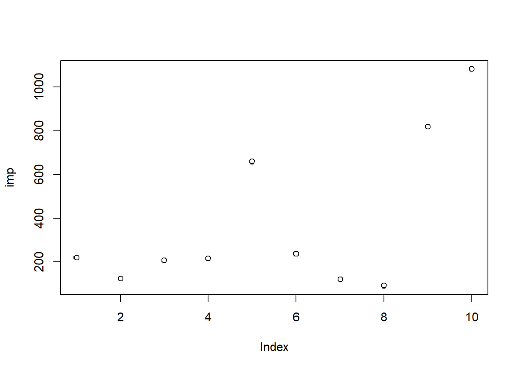

```r
plot(imp)
```

### Comparing with the important features from the decision tree to narrow down choices for the neural net

Important: - Weight in grams - Discount offered - Cost of product - Prior purchases

Not important: - Gender - Mode of shipment - Product importance

Unimportant to one model but mid level to another: - Warehouse block - CUstomer rating - Customer care calls

## Neural Net

The next model I did was a Neural Net. Neural nets use scaled numeric data, so I used the version of the data set that I did data transformations on to generate my training and testing sets.

```r
set.seed(5)

shipping_new$Reached.on.Time_Y.N = as.factor(shipping_new$Reached.on.Time_Y.N)
sample = sample.split(shipping_new, SplitRatio = .75)
NNtrain = subset(shipping_new, sample == TRUE)
NNtest  = subset(shipping_new, sample == FALSE)
```

I intended to build a few different neural nets to compare. The first one was predicting Reached on time from two features, Weight in grams and Discount offered. These were the two most important features to both the decision tree and the random forest. This ANN has one hidden layer with 3 nodes, and uses the logistic activation function.

1. Weight in grams & Discount offered

```r
NN = neuralnet(Reached.on.Time_Y.N ~ Weight_in_gms + Discount_offered, NNtrain, hidden = 3, act.fct = "logistic", linear.output = F)

# plot neural network
plot(NN)
```

```r
predict_testNN = compute(NN, NNtest[,-7])

prob = predict_testNN$net.result

pred <- ifelse(prob[,2]>0.5, 1, 0)

predFactor <- as.factor(pred)

confusionMatrix(predFactor,NNtest$Reached.on.Time_Y.N)
```

```
## Confusion Matrix and Statistics
##
##           Reference
## Prediction    0    1
##          0  840  593
##          1  309 1007
##
##                Accuracy : 0.6719
##                  95% CI : (0.654, 0.6894)
##     No Information Rate : 0.582
##     P-Value [Acc > NIR] : < 2.2e-16
##
##                   Kappa : 0.3483
##
##  Mcnemar's Test P-Value : < 2.2e-16
##
##             Sensitivity : 0.7311
##             Specificity : 0.6294
##          Pos Pred Value : 0.5862
##          Neg Pred Value : 0.7652
##              Prevalence : 0.4180
##          Detection Rate : 0.3056
##    Detection Prevalence : 0.5213
##       Balanced Accuracy : 0.6802
##
##        'Positive' Class : 0
##
```

A neural net using Weight and grams and discount offered as inputs is around 67% accurate.

My next neural net was going to be adding in the next two most important features, but I could not get one to converge. Instead, my next neural net has the three most important features. This one adds Cost of the product to the features used in the previous neural net.

2. Weight in grams, Discount offered, Cost of product, & Prior purchases

```r
#NN = neuralnet(Reached.on.Time_Y.N ~ Weight_in_gms + Discount_offered + Cost_of_the_Product + Prior_purchases, datatrain, hidden = c(3,3), act.fct = "logistic", linear.output = F)

# plot neural network
#plot(NN)
```

```r
#NN = neuralnet(Reached.on.Time_Y.N ~ Weight_in_gms + Discount_offered + Cost_of_the_Product + Prior_purchases, datatrain, hidden = 5, act.fct = "logistic", linear.output = F)

# plot neural network
#plot(NN)
```

2. Weight in grams, Discount offered, Cost of product

```r
NN = neuralnet(Reached.on.Time_Y.N ~ Weight_in_gms + Discount_offered + Cost_of_the_Product, NNtrain, hidden = 5, act.fct = "logistic", linear.output = F)

# plot neural network
plot(NN)
```

```r
predict_testNN = compute(NN, NNtest[,-7])

prob = predict_testNN$net.result

pred <- ifelse(prob[,2]>0.5, 1, 0)

predFactor <- as.factor(pred)

confusionMatrix(predFactor,NNtest$Reached.on.Time_Y.N)
```

```
## Confusion Matrix and Statistics
##
##           Reference
## Prediction    0    1
##          0 1101  775
##          1   48  825
##
##                Accuracy : 0.7006
##                  95% CI : (0.6831, 0.7177)
##     No Information Rate : 0.582
##     P-Value [Acc > NIR] : < 2.2e-16
##
##                   Kappa : 0.4351
##
##  Mcnemar's Test P-Value : < 2.2e-16
##
##             Sensitivity : 0.9582
##             Specificity : 0.5156
##          Pos Pred Value : 0.5869
##          Neg Pred Value : 0.9450
##              Prevalence : 0.4180
##          Detection Rate : 0.4005
##    Detection Prevalence : 0.6824
##       Balanced Accuracy : 0.7369
##
##        'Positive' Class : 0
##
```

A neural net using the 3 most important features is around 70% accurate.

## SVM

For SVM, I am using the same training and testing sets as in the neural net because SVM requires numeric, scaled data.

1. SVM with all features

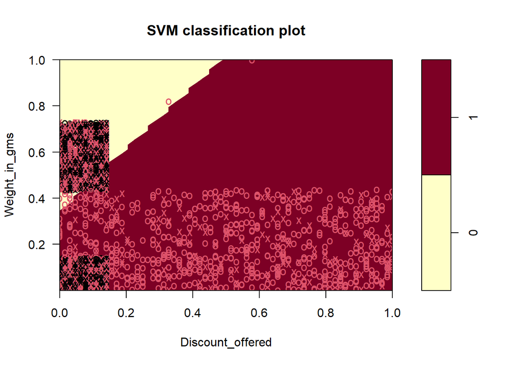

```r
classifier = svm(formula = Reached.on.Time_Y.N ~ .,
                 data = NNtrain,
                 type = 'C-classification',
                 kernel = 'linear')

# plot

plot(classifier, NNtest,  Weight_in_gms ~ Discount_offered)
```

```r
# Predicting the Test set results
y_pred = predict(classifier, newdata = NNtest[-7])

# Making the Confusion Matrix
cm = table(NNtest[, 7], y_pred)

accuracy_Test <- sum(diag(cm)) / sum(cm)
accuracy_Test
```

```
## [1] 0.6653328
```

A SVM with all of the features is around 66% accurate.

2. SVM with 2 most important features - Weight in grams and Discount offered

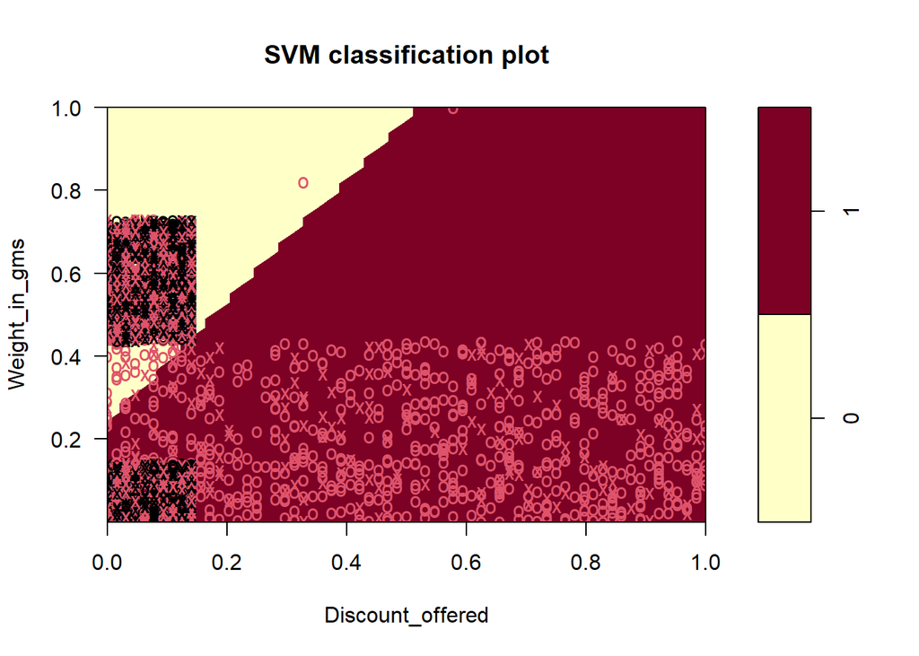

```r
classifier = svm(formula = Reached.on.Time_Y.N ~  Weight_in_gms + Discount_offered,
                 data = NNtrain,
                 type = 'C-classification',
                 kernel = 'linear')

## plot

plot(classifier, NNtest,  Weight_in_gms ~ Discount_offered)
```

```r
# Predicting the Test set results
y_pred = predict(classifier, newdata = NNtest[-7])

# Making the Confusion Matrix
cm = table(NNtest[, 7], y_pred)

accuracy_Test <- sum(diag(cm)) / sum(cm)
accuracy_Test
```

```
## [1] 0.6606039
```

SVM with the two most important features is around 66% accurate.

## Comparison

Decision tree - 0.6813333

Random forest - 0.6673333

NN with 2 most important features - 0.6719

NN with 3 most important features - 0.7006

SVM with all features - 0.6653328

SVM with 2 most important features - 0.6606039

Looking at all of the models and their accuracy, they are all fairly close to each other around 66% accurate. The most accurate model with the ANN with the 3 most important features, which was around 70% accurate.